# STOCK DE SEGURIDAD

Limber López

7/3/2021

# Encabezado con logotipo de la universidad

## UNIVERSIDAD CATOLICA BOLIVIANA “SAN PABLO”

[figure not shown]

La Paz - Bolivia

# Fotografía pequeña de los integrantes del grupo y sus correos electrónicos

Limber López

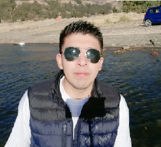

raul10lop@gmail.com

# Situación problema que tratarás en el trabajo

## Problema de inventarios de seguridad

El stock de seguridad es el inventario extra que se tiene en el depósito para hacer frente a imprevistos relacionados con cambios en la demanda o retrasos de los proveedores. El objetivo de mantener existencias de seguridad es evitar caer en una rotura de stock.

Serigrafía Geele SRL, empresa dedicada a la impresión serigráfica de envases plásticos cuenta con su línea de impresión PINTURA EPOXICA, la misma tiene una capacidad de impresíon de 3000 unidades/día en envases de 18 a 20 litros.

Actualmente se tiene un problema de sobredimensionamiento del stock de seguridad, esto debido a la variación de la demanda.

# Identificación de al menos 3 artículos científicos y un libro en el que puedas encontrar soluciones propuestas a la situación problema

## 1er Modelo

Para realizar el cálculo del stock de seguridad es:
$$SS=(PME - PE)*DM$$
Donde:

- PME: El plazo máximo de entrega en el que el proveedor nos haga llegar el producto suponiendo que hubiera un retraso.
- PE: El plazo de entrega normal en el que el proveedor nos envía la mercancía en circunstancias normales.
- DM: La demanda media que se ha calculado para ese producto determinado en una situación de normalidad.

## 2do Modelo

$$SS=z*\sigma_t* D_p$$
Donde:

- z: es el nivel de servicio deseado.
- σ_t: es la desviación estandar del tiempo de entrega.
- Dp: Demanda promedio.

## 3er Modelo

Este modelo es útil para compañías que cuenten con estadísticas de ventas por, al menos, un año. Esto, con el objetivo de medir con mayor exactitud el uso diario máximo y promedio.
$$SS= (DM*PME)-(DP-PEP)$$
Donde:

- DM: Demanda máxima.
- PME: Plazo de entrega máximo.
- DP: Demanda promedio.
- PEP: Plazo de entrega promedio.

## “Gestión Logística y Comercial”

de Ana Maria Cruz Herradón, Sandra Rosario de Prado Morante y Pilar Meseguer Galán

$$SS= Dd*(dr-d)$$
Donde:

- Dd: Demanda o consumo diario.
- dr: Plazo de entrega del proveedor con posibles días de retraso.
- d: Plazo de entrega

# Disponer de un dataset (puede ser datos de excel) sobre la situación problema (Si no dispones de datos puedes buscarlos en sitios como Kaggle

```r
library(readxl)
library(readxl)
ENVASES <- read_excel("C:/TRABAJO FINAL RSTUDIO/ENVASES.xlsx",
    sheet = "linea latex", range = "A1:D13")

ENVASES[c(1:13),]
```

```
## # A tibble: 13 x 4
##    TIEMPO `ENTRADA DE MATERIAL` `DEMANDA INTERNA` `STOCK DE SEGURIDAD`
##     <dbl>                 <dbl>             <dbl>                <dbl>
##  1      1                 10000              7000                 3000
##  2      2                     0              2000                 1000
##  3      3                  5500              5000                 1500
##  4      4                  3000              3000                 1500
##  5      5                  3000              2000                 2500
##  6      6                     0              1000                 1500
##  7      7                  5000              4000                 2500
##  8      8                     0              1000                 1500
##  9      9                  3000              2000                 2500
## 10     10                  4000              3000                 3500
## 11     11                     0              1500                 2000
## 12     12                     0              2000                    0
## 13     NA                    NA                NA                   NA
```

# Hacer un análisis exploratorio de los datos

```r
summary(ENVASES)
```

```
##      TIEMPO      ENTRADA DE MATERIAL DEMANDA INTERNA STOCK DE SEGURIDAD
##  Min.   : 1.00   Min.   :    0       Min.   :1000    Min.   :   0
##  1st Qu.: 3.75   1st Qu.:    0       1st Qu.:1875    1st Qu.:1500
##  Median : 6.50   Median : 3000       Median :2000    Median :1750
##  Mean   : 6.50   Mean   : 2792       Mean   :2792    Mean   :1917
##  3rd Qu.: 9.25   3rd Qu.: 4250       3rd Qu.:3250    3rd Qu.:2500
##  Max.   :12.00   Max.   :10000       Max.   :7000    Max.   :3500
```

# Establecer si existe correlación entre las columnas del dataset

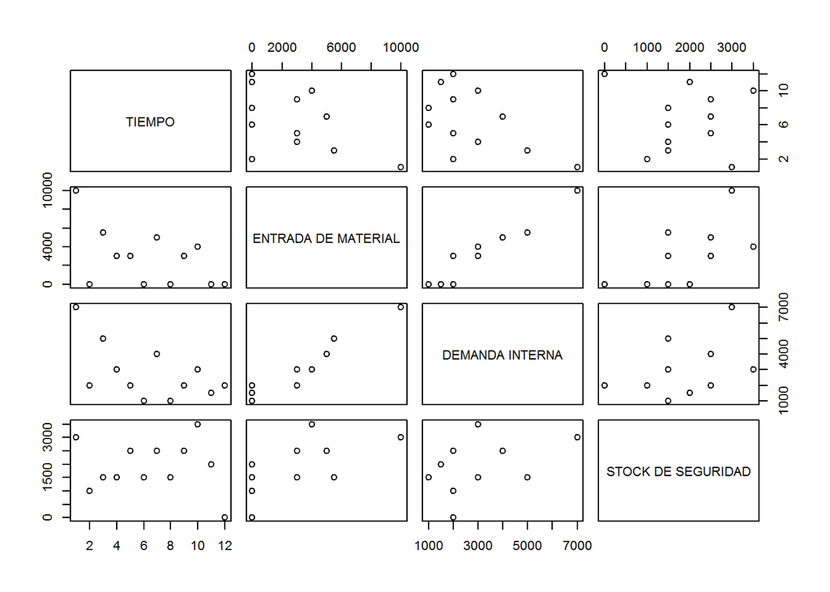

```r
library(psych)
pairs(ENVASES[c(1,2,3,4)])
```

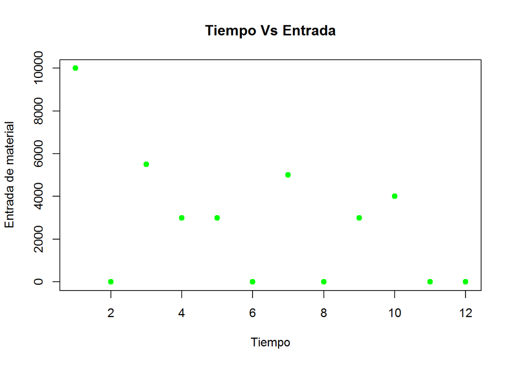

```r
plot(ENVASES$TIEMPO,ENVASES$`ENTRADA DE MATERIAL`, pch=19, col="green",xlab="Tiempo", ylab="Entrada de material", main="Tiempo Vs Entrada")
```

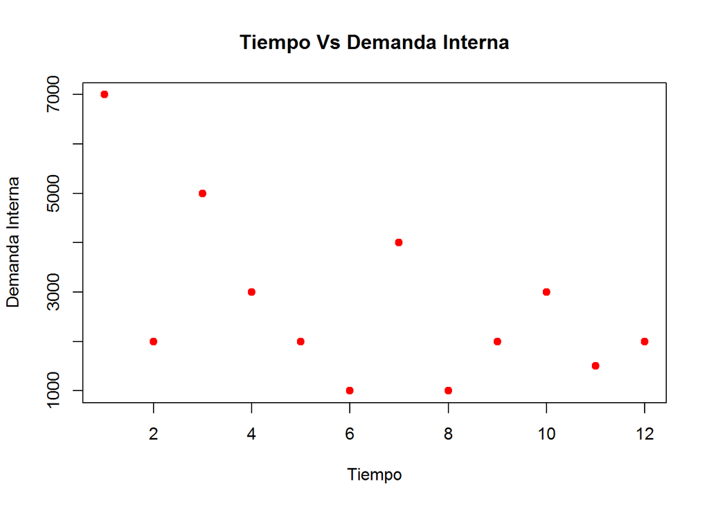

```r
plot(ENVASES$TIEMPO,ENVASES$`DEMANDA INTERNA`, pch=19, col="red",xlab="Tiempo", ylab="Demanda Interna", main="Tiempo Vs Demanda Interna")
```

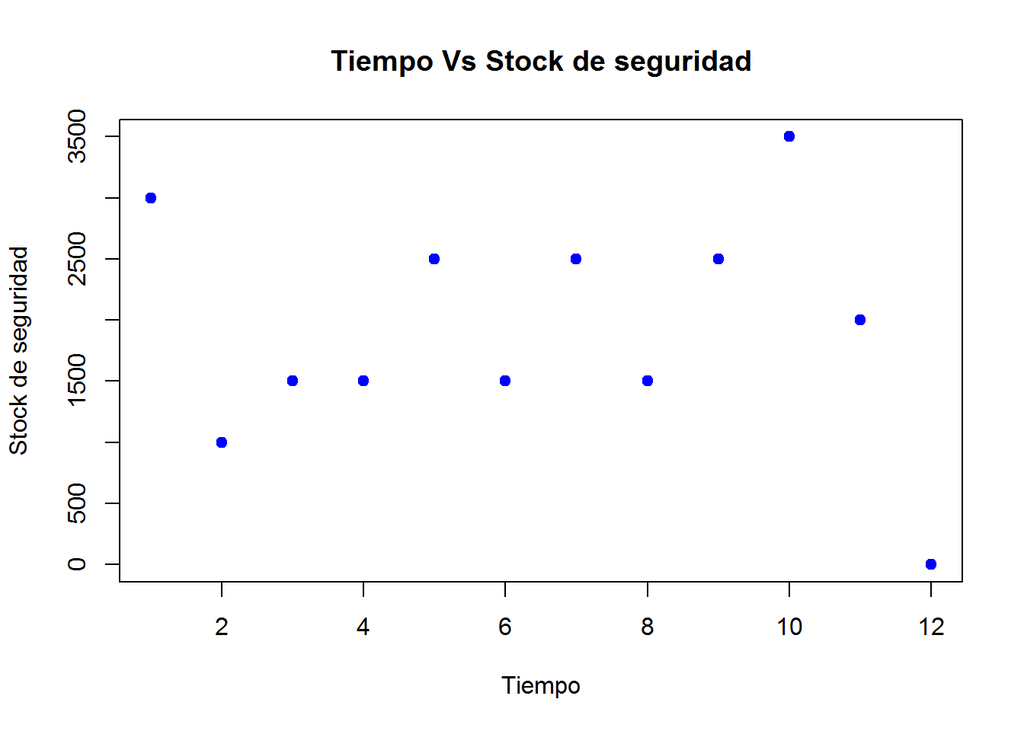

```r
plot(ENVASES$TIEMPO,ENVASES$`STOCK DE SEGURIDAD`, pch=19, col="blue",xlab="Tiempo", ylab="Stock de seguridad", main="Tiempo Vs Stock de seguridad")
```

# Hacer un gráfico de matriz de covarianza

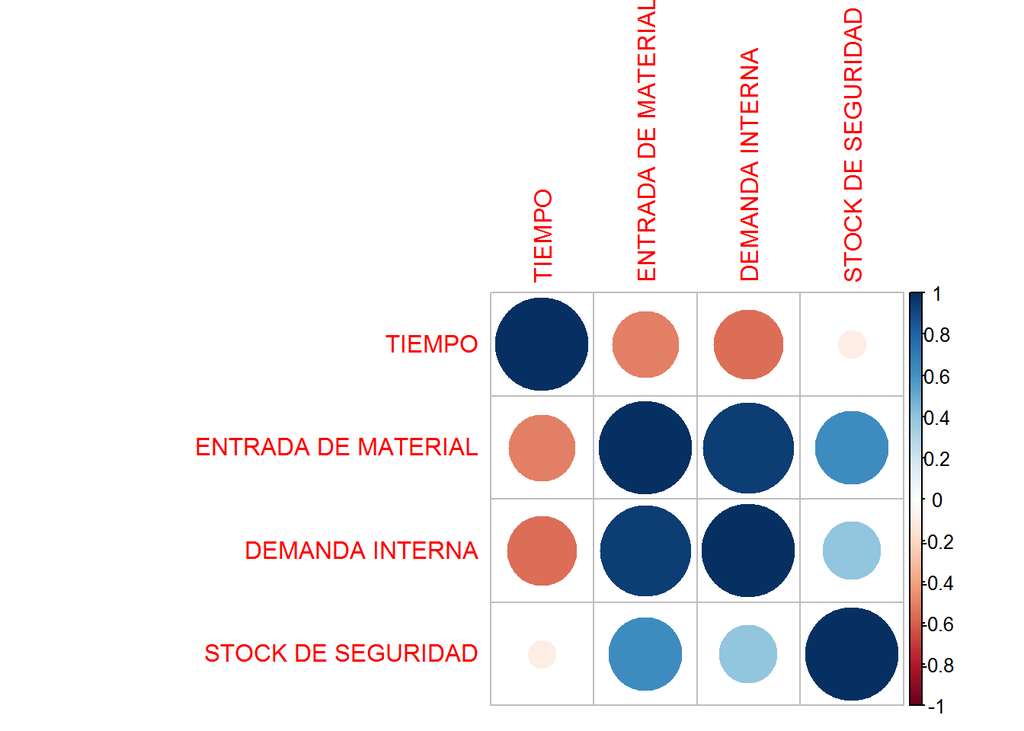

```r
library(corrplot)
M<- cor(ENVASES)
corrplot::corrplot(M, method = "circle")
```

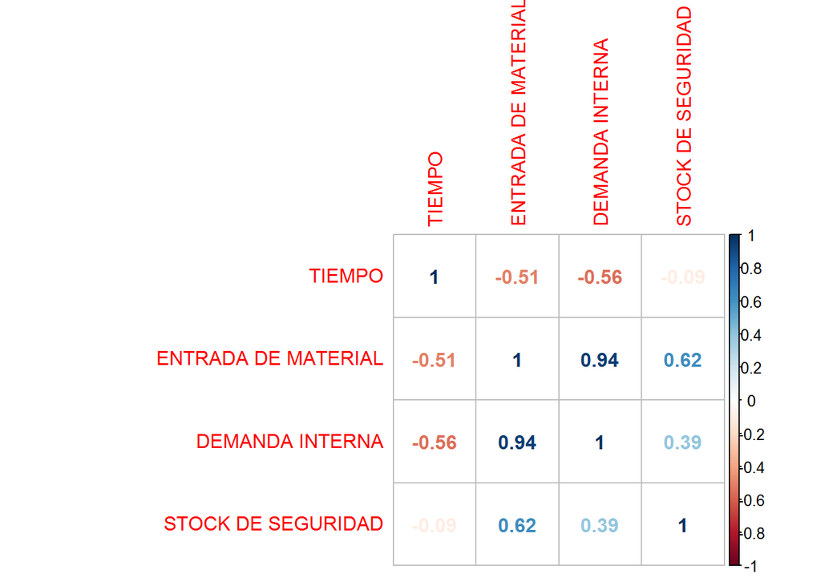

```r
corrplot::corrplot(M, method = "number")
```

# Estudiar el histograma , el gráfico de densidad y los cuantiles de la variable que más impacta sobre el problema.

## Histogramas

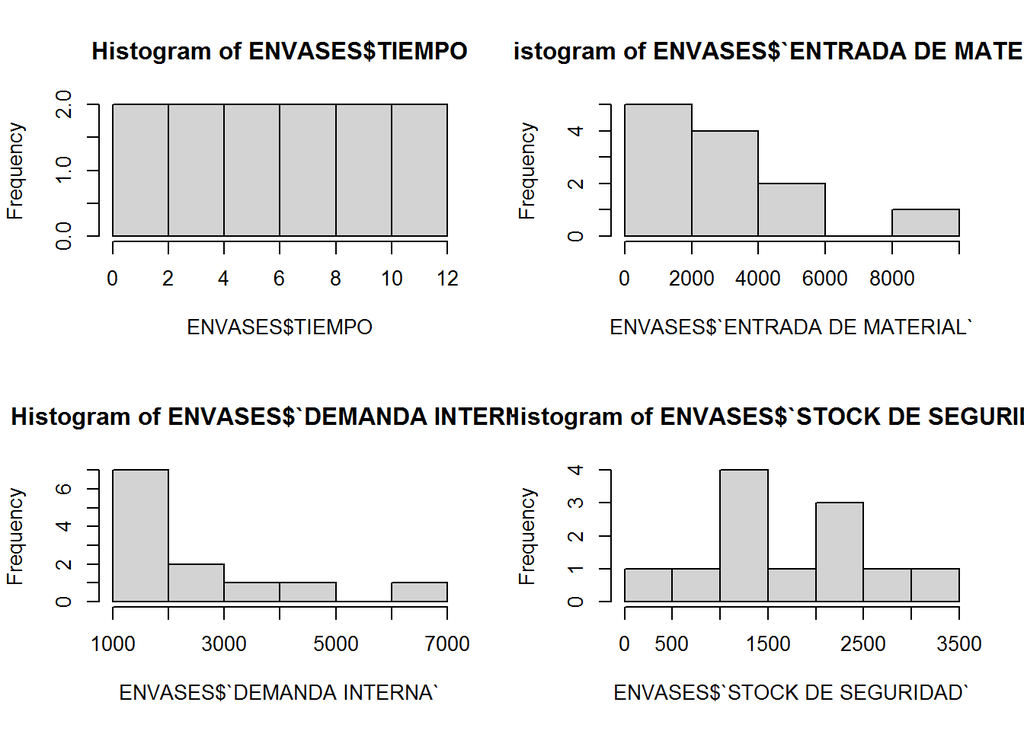

```r
par(mfrow=c(2,2))

hist(ENVASES$TIEMPO)
hist(ENVASES$`ENTRADA DE MATERIAL`)
hist(ENVASES$`DEMANDA INTERNA`)
hist(ENVASES$`STOCK DE SEGURIDAD`)
```